[figure not shown]

WI-447

Instrument Panel Wiring Harness RH

WIRING SYSTEM

67.Instrument Panel Wiring Harness RH

A: LOCATION

Connector Connecting to

No. Pole Color Area No. Description

AD15 4 GR B-2

Audio (without navigation)

Navigation unit (with navigation)

AD16 4 GR D-4 AUX input terminal (USB)

i7 4 GR B-2 MFD switch

i9 2 C-2 Pocket light

i22 4 B-2 Hazard switch

i23 2 B-4 Glove box illumi. light

i24 2 C-2 Front accessory power supply socket

i29 1 B-2 Audio bracket ground

i50 10 B-2 Navigation unit

i53 24 C-4 R98 Rear wiring harness RH

i76 28 B-4 D83 Front door cord RH

i85 20 B-2

Audio

i86 16 B-2

i87 28 B-2 Navigation unit

i88 40 C-2 A/C control panel (auto A/C)

i89 3 A-3 Auto light sensor

i131 6 B-2

Navigation unit

i146 16 B-2

i159

2 A-4 Side tweeter RH (without audio amplifier)

4 A-4 Side tweeter RH (with audio amplifier)

i168 4 B-3

J/C

i169 4 B-3

i195 20 C-4 R382 Rear wiring harness RH

i237 12 B-3 B583

Bulkhead wiring harness

i238 20 B-3 B584

White or natural color

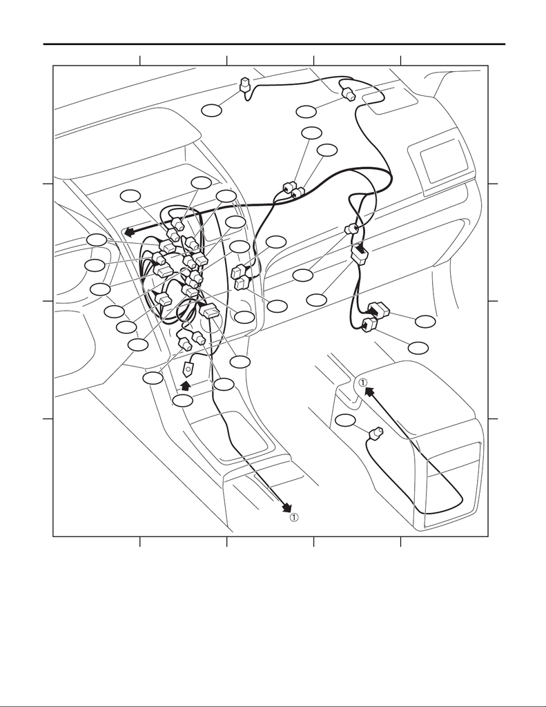

12345

12345

A

B

C

D

A

B

C

D

LH

i29

i87

AD15

i7

i146

i22

i76

i23

i195

i53

i168

i169

i89

i159

i131

i88

AD16

i238

i50

AD15

i29

i237

i85

i86

i24

i9

GB-7

*1

*4

*2

*3

3:WITH NAVIGATION

2:STANDARD MODEL

1:PREMIUM MODEL

4:WITHOUT NAVIGATION